← nabídka úloh

# S05 – Tetris: váhy, které vydrží i na nových hrách

**Simulační úloha S05 · řešení patří do složky `simulacni-uloha/` vašeho repozitáře · simulátor a data: data-S05.zip (rozbalit do `simulacni-uloha/`; simulátor k náhledu: simulator.py)**

Počítačový hráč Tetrisu nemusí umět nic chytrého. U každého dílku vyzkouší všechna místa, kam ho jde položit, u každého se podívá, jak by deska potom vypadala, a vybere to místo, které podle jednoduchého vzorce „vypadá nejlíp“. Celá jeho inteligence je v osmi číslech – vahách, které říkají, jak moc vadí díra, vysoká stavba nebo hluboká studna. Výsledek hry ale hodně závisí na tom, jaké dílky zrovna přijdou, takže ladění vah je optimalizace se šumem – a je snadné uvěřit jedné šťastné hře.

*Hry jsou simulované, dílky generuje simulátor ze seedu.*

## Co potřebujete vědět o Tetrisu a hráči

**Hra.** Deska má 6 sloupců a 12 řádků (menší než klasických 10 × 20 – na velké desce by dobrý hráč hrál hodiny). Dílky I, O, T, S, Z, J, L přicházejí náhodně, každý se stejnou pravděpodobností; dá se otočit a posunout do libovolného sloupce a pak spadne svisle dolů. Plná řada zmizí a stavba nad ní sjede dolů. Hra končí, když se další dílek nevejde, nebo po 500 dílcích (víc než 333 řad v jedné hře tedy udělat nejde).

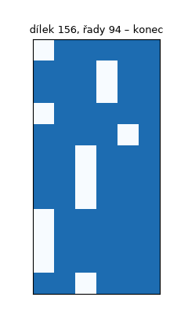

Jedna hra hráče s dobrými váhami na desce 6 × 12. Tahle skončila po 94 řadách, i když stejné váhy v jiných hrách dojdou až do limitu 500 dílků: délka hry je hodně náhodná (první snímek je konec hry).

**Hráč.** Pro každé možné umístění spočítá simulátor osm *rysů* desky (po dopadu a smazání řad):

| # | rys | význam |
| --- | --- | --- |
| 0 | výška dopadu | jak vysoko dílek dopadl |
| 1 | erodované buňky | smazané řady × kolik buněk dílku v nich bylo |
| 2 | přechody v řádcích | kolikrát se v řádku střídá plná a prázdná buňka (stěny jsou plné) |
| 3 | přechody ve sloupcích | totéž ve sloupcích (dno je plné) |
| 4 | díry | prázdné buňky, nad kterými je ve sloupci něco plného |
| 5 | studny | úzké šachty mezi plnými sousedy, hlubší váží víc |
| 6 | hloubka děr | kolik plných buněk leží nad dírami |
| 7 | řádky s dírami | počet řádků, ve kterých je aspoň jedna díra |

Hráč vybere umístění s největším skóre $s = \sum_{i=0}^{7} w_i f_i$, kde $f_i$ jsou rysy a $w_i$ váhy (kladné i záporné). Dopředu se nedívá, zná jen aktuální dílek. Přesné definice rysů jsou v kódu simulátoru.

**Odkud se to vzalo.** Rysy pocházejí z literatury o počítačovém Tetrisu. Pierre Dellacherie vyladil šest vah ručně, $\mathbf w = (-1, 1, -1, -1, -4, -1, 0, 0)$; Thiery a Scherrer publikovali osm vah (BCTS) $\mathbf w = (-12{,}63;\ 6{,}60;\ -9{,}22;\ -19{,}77;\ -13{,}08;\ -10{,}49;\ -1{,}61;\ -24{,}04)$. Obě sady byly laděné na velké desce – jak se osvědčí na malé, nevíte.

## Simulátor

`simulator.py` (jen NumPy) má jednu funkci:

```python
hraj(vahy, seedy, sirka=6, vyska=12, max_dilku=500, zaznam=False)
```

- `vahy` – pole 8 čísel (stejné pro všechny hry), nebo pole tvaru `(len(seedy), 8)`, kde má každá hra vlastní váhy;
- `seedy` – celá čísla, jedna hra na seed; stejný seed = stejné dílky;
- vrací slovník polí: `rady` (smazané řady v každé hře – to chcete maximalizovat) a `dilky` (počet položených dílků);
- `zaznam=True` navíc vrátí `desky` – stav desky první hry po každém dílku (každý řádek jako celé číslo, bit $c$ = sloupec $c$), hodí se na animaci.

Hry v jednom volání se simulují najednou, takže jedno volání s 50 hrami je výrazně rychlejší než 50 volání po jedné. Jedna dobrá hra trvá desetiny sekundy. `sirka`, `vyska` a `max_dilku` nechte ve výchozím nastavení (změna je jen pro vlastní experiment).

**Rozpočet.** Jeden běh optimalizace smí odehrát nejvýš **1000 her** (každá hra s jedním seedem se počítá, i opakovaná). Hry, na kterých výsledek ověřujete, se do rozpočtu nepočítají, ale **nesmí to být hry, na kterých jste ladili**.

## Úkol

### Základní úloha

Najděte váhy, se kterými hráč smaže v průměru co nejvíc řad. Je to black-box úloha se šumem: skóre je po částech konstantní funkce vah, bez gradientu. Použijte aspoň tři metody z kurzu (náhodné hledání jako baseline a aspoň dvě další, např. evoluční strategie, CMA-ES, metodu křížové entropie, genetický algoritmus, Optunu) a srovnejte je férově: stejný rozpočet her, víc nezávislých běhů s různými seedy, medián a rozptyl. Váhy z literatury berte jako srovnání.

### Nový požadavek

Hráč půjde do turnaje na **hrách, které nikdo předem neviděl**. Pořadatel píše: „Zajímá mě, kolik řad váš hráč udělá na mých hrách, ne kolik jich udělal u vás doma. Před turnajem mi pošlete váhy **a číslo**, kolik řad v průměru čekáte. Kdo slíbí víc, než pak udělá, dostane srážku.“

Rozhodněte, jak v rámci stejného rozpočtu naložit se šumem (kolik her dát na jedno vyhodnocení, co vlastně metoda vrátí jako výsledek) a jak se změní pořadí metod, když se díváte na skutečný výkon na nových hrách. Pořadateli pošlete váhy a odhad, za kterým si stojíte.

### Co má vaše práce ukázat

- Srovnání aspoň tří metod při stejném rozpočtu na víc seedech (medián, kvartily, boxplot) – a to jak podle skóre, které metoda během ladění naměřila, tak podle skóre na nových hrách. Shodují se?
- Co stál a co přinesl jiný počet her na jedno vyhodnocení při pevném rozpočtu.
- Nezávislou kontrolu: výsledné váhy přehrajte na dostatečném počtu nových her a odhadněte, jak přesně svůj výsledek znáte. Srovnejte je s vahami z literatury.
- Číslo pro pořadatele: jak jste ho získali a jak by dopadlo, kdybyste poslali to, co naměřil optimalizátor.
- Vlastní experiment s jasnou otázkou, tabulkou nebo grafem a závěrem.

## Otázky k zamyšlení

- Proč se metody seřadí tak, jak se seřadily, a platí to pořadí i s jiným počtem her na vyhodnocení?
- Simulátor dává stejné rozhodnutí pro váhy $\mathbf w$ a $2\mathbf w$. Co to dělá s krajinou, kterou optimalizátor prohledává?
- Kolik nových her potřebujete, abyste mohli říct, že jedny váhy jsou lepší než druhé?
- Kde jinde v biologii, medicíně nebo strojovém učení byste narazili na podobnou situaci jako se slibem pořadateli?

## Co odevzdáváte

Řešení patří do složky **`simulacni-uloha/`** vašeho týmového repozitáře (šablona projektu). Archiv data-S05.zip obsahuje jen `simulator.py`; rozbalte ho přímo do této složky, vedle `reseni.py`. Simulátor neupravujte.

- **Kód**, který jedním příkazem (`uv run python simulacni-uloha/reseni.py`) přepočítá všechny výsledky, tabulky a grafy do `simulacni-uloha/vystupy/`. Jak kód rozdělíte do funkcí a souborů, je na vás. Pokud celý běh trvá dlouho, popište, jak spustit zkrácenou verzi.
- **`simulacni-uloha/README.md`** podle šablony: účelová funkce, metody a jejich nastavení, rozpočet, výsledky, interpretace a kontroly. Uveďte, co jste oproti zadání změnili a proč.
- **Testy** (`uv run pytest simulacni-uloha`), mezi nimi aspoň jeden, který odhalí záměrně pokažené řešení (např. váhy vyhodnocené na hrách, na kterých se ladilo, nebo překročený rozpočet).

Hodnotí se, co z výsledků vyčtete a jestli to umíte obhájit, ne shoda s nějakým referenčním číslem. U obhajoby počítejte s otázkou „co když“: malou změnou zadání (např. rozpočet klesne na 300 her, deska bude o sloupec užší), kterou musíte umět promítnout do svého postupu.

## Náměty na rozšíření

- **Společné hry.** Co když porovnávaná řešení hrají na stejných hrách?
- **Méně rysů.** Které rysy jsou potřeba? Co se stane, když některé váhy zafixujete na nulu?
- **Animace.** Hra vašeho nejlepšího hráče jako GIF – a hra, ve které prohrál.
- **Jiná deska.** Přenesou se váhy na užší nebo vyšší desku?